# Sensor Noise Report

Mazama Science

6/17/2020

### Sensor Multi-plot

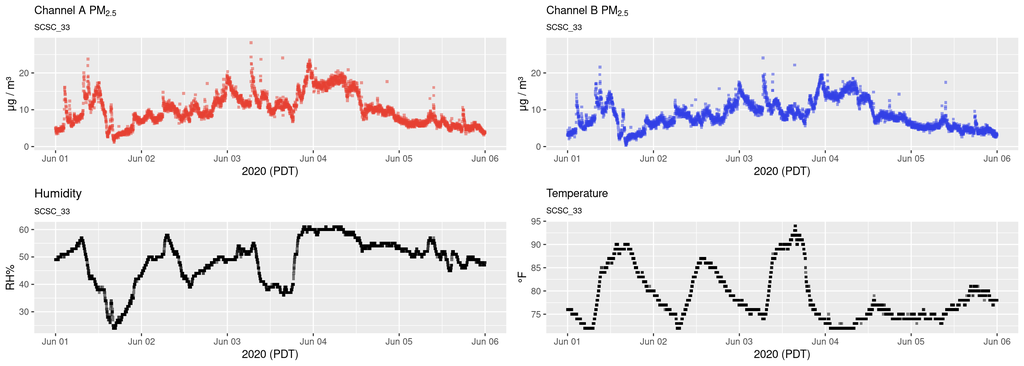

```r
multi_plot <- pat_multiPlot(pat)
multi_plot
```

### Sensor State of Health (Daily)

PurpleAir daily state-of-health (`pat_dailySoH()`) applies six algorithms: - `PurpleAirSoH_dailyPctDC` - `PurpleAirSoH_dailyPctReporting` - `PurpleAirSoH_dailyPctValid` - `PurpleAirSoH_dailyOtherFit` - `PurpleAirSoH_dailyABFit` - `PurpleAirSoH_dailyABtTest`

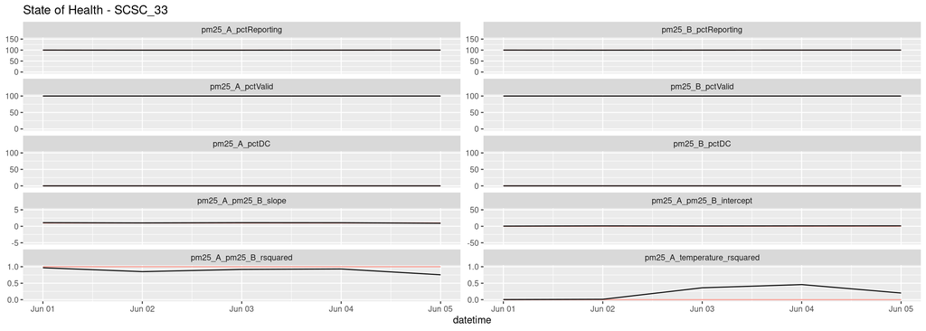

```r
pat_soh <- pat_dailySoHPlot(pat)
pat_soh
```

See `?pat_dailySoH`, `?PurpleAirSoH_dailyPctDC`, `?PurpleAirSoH_dailyPctReporting`, `?PurpleAirSoH_dailyPctValid`, `?PurpleAirSoH_dailyPctValid`, `?PurpleAirSoH_dailyOtherFit`, `?PurpleAirSoH_dailyABFit`, and `?PurpleAirSoH_dailyABtTest` for more details.

### PurpleAir Quality-Control 00

Creates a `pm25` timeseries by averaging aggregated data from the A and B channels and applying the following QC logic:

- Create pm25 by averaging the A and B channel aggregation means
- Invalidate data where: (min_count < 20)

```r
qc_00 <- pat_monitorComparison(pat, FUN = AirSensor::PurpleAirQC_hourly_AB_00)
qc_00
```

[output not shown]

See `?AirSensor::PurpleAirQC_hourly_AB_00` for more details regarding the quality-control algorithm.

### PurpleAir Quality-Control 01

Creates a `pm25` timeseries by averaging aggregated data from the A and B channels and applying the following QC logic:

- Create pm25 by averaging the A and B channel aggregation means
- Invalidate data where: (min_count < 20)
- Invalidate data where: (p-value < 1e-4) & (mean_diff > 10)
- Invalidate data where: (pm25 < 100) & (mean_diff > 20)

```r
qc_01 <- pat_monitorComparison(pat, FUN = AirSensor::PurpleAirQC_hourly_AB_01)
qc_01
```

[output not shown]

See `?AirSensor::PurpleAirQC_hourly_AB_01` for more details regarding the quality-control algorithm.

### PurpleAir Quality-Control 02

Creates a `pm25` timeseries by averaging aggregated data from the A and B channels and applying the following QC logic:

- Create pm25 by averaging the A and B channel aggregation means
- Invalidate data where: (min_count < 20)
- Invalidate data where: (A/B hourly median-absolute-deviation (MAD) > 3)
- Invalidate data where: (A/B hourly percent difference (pct_diff) > 0.5)

```r
qc_02 <- pat_monitorComparison(pat, FUN = AirSensor::PurpleAirQC_hourly_AB_02)
qc_02
```

[output not shown]

See `?AirSensor::PurpleAirQC_hourly_AB_02` for more details regarding the quality-control algorithm.

### PurpleAir Quality-Control 03

Creates a `pm25` timeseries by averaging aggregated data from the A and B channels and applying the following QC logic:

- Create pm25 by averaging the A and B channel aggregation means
- Invalidate data where: (min_count < 20)
- Invalidate data where: (A/B hourly difference > 5 AND A/B hourly percent difference > 70%)
- Invalidate data where: (A/B hourly data recovery < 90%)

```r
qc_03 <- pat_monitorComparison(pat, FUN = AirSensor::PurpleAirQC_hourly_AB_03)
qc_03
```

[output not shown]

See `?AirSensor::PurpleAirQC_hourly_AB_03` for more details regarding the quality-control algorithm.

*Mazama Science*